# Regressão Linear - Projeto

### Análise entre "Time on App" e "Length of Membership"

**Vamos explorar esses tipos de relações em todo o conjunto de dados. Use [parplot](https://stanford.edu/~mwaskom/software/seaborn/tutorial/axis_grids.html#plotting-pairwise-relationships-with-pairgrid-and-pairplot) para recriar o gráfico abaixo. (Não se preocupe com as cores)***

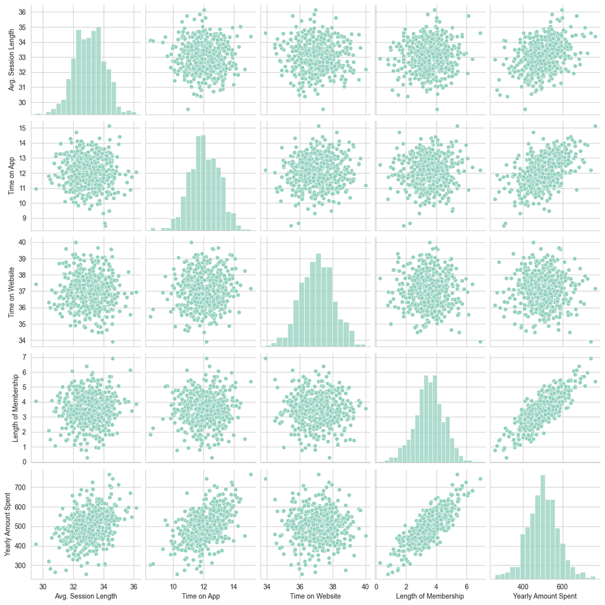

```python
sns.pairplot(clientes)
```

Baseado neste plot o que parece ser a característica mais correlacionada com o valor anual gasto (Yearly Amount Spent)?

Crie um plot de um modelo linear (usando o lmplot de Seaborn) da quantia anual gasta (Yearly Amount Spent) vs. tempo de associação (Length of Membership).

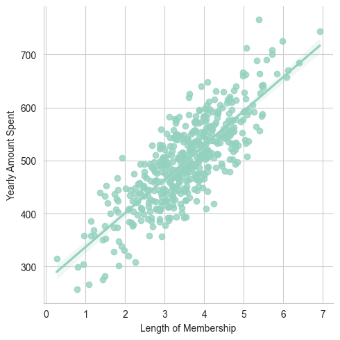

```python
sns.lmplot(x="Length of Membership", y="Yearly Amount Spent", data=clientes)
```

### Análise entre "Length of Membership" e "Yearly Amount Spent"

O gráfico de regressão linear entre "Length of Membership" e "Yearly Amount Spent" mostra uma forte relação positiva: quanto maior o tempo de associação do cliente, maior tende a ser o valor anual gasto. Os pontos seguem uma tendência linear bem definida, indicando que o tempo como membro é um dos principais fatores associados ao aumento dos gastos anuais dos clientes.

## Treinando e testando os dados

Agora que exploramos um pouco os dados, vamos avançar e dividir os dados em conjuntos de treinamento e teste. Defina uma variável X igual a todas as características numéricas dos clientes e uma variável y igual à coluna Valor anual gasto (Yearly Amount Spent).

```python
y = clientes["Yearly Amount Spent"]
```

```python
X = clientes[
    ["Avg. Session Length", "Time on App", "Time on Website", "Length of Membership"]
]
```

```python
from sklearn.model_selection import train_test_split
```

```python
X_train, X_test, y_train, y_test = train_test_split(
    X, y, test_size=0.3, random_state=42
)
```

## Treinando o modelo

Agora é hora de treinar nosso modelo em nossos dados de treinamento!

Importe LinearRegression do sklearn.linear_model

```python
from sklearn.linear_model import LinearRegression
```

Crie uma instância de um modelo LinearRegression () chamado lm.

```python
lm = LinearRegression(n_jobs=-1)
```

Treine lm nos dados de treinamento.

```python
lm.fit(X_train, y_train)
```

```
LinearRegression(n_jobs=-1)
```

**Print os coeficientes do modelo**

```python
print("Coefficients: \n", lm.coef_)
```

```
Coefficients:
 [25.72425621 38.59713548  0.45914788 61.67473243]
```

## Previsão de dados de teste

Agora que nos ajustamos ao nosso modelo, vamos avaliar o seu desempenho ao prever os valores de teste!

Use lm.predict () para prever o conjunto X_test dos dados.

```python
predictions = lm.predict(X_test)
```

Crie um diagrama de dispersão (scatterplot) dos valores reais de teste em relação aos valores preditos.

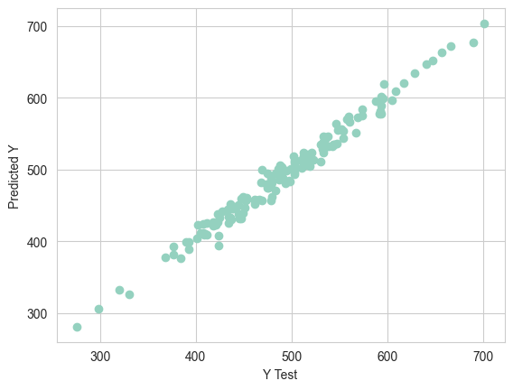

```python
plt.scatter(y_test, predictions)
plt.xlabel("Y Test")
plt.ylabel("Predicted Y")
```

### Análise do gráfico de dispersão entre valores reais e preditos

O gráfico de dispersão entre os valores reais (y_test) e os valores preditos pelo modelo mostra que os pontos estão próximos de uma linha reta, indicando que as previsões do modelo estão alinhadas com os valores reais. Isso sugere que o modelo de regressão linear apresenta bom desempenho, com baixa dispersão dos resíduos e boa capacidade de previsão.

## Avaliando o Modelo

Calcule o erro absoluto médio, o erro quadrado médio e o erro quadrado médio da raiz. Consulte a palestra ou a Wikipédia para as fórmulas.

```python
from sklearn import metrics

print("MAE:", metrics.mean_absolute_error(y_test, predictions))
print("MSE:", metrics.mean_squared_error(y_test, predictions))
print("RMSE:", np.sqrt(metrics.mean_squared_error(y_test, predictions)))
```

```
MAE: 8.426091641432068
MSE: 103.9155413650325
RMSE: 10.193897260863114
```

## Resíduos

Você deve ter obtido um modelo muito bom com um bom ajuste. Vamos explorar rapidamente os resíduos para garantir que tudo esteja bem com os nossos dados.

Trace um histograma dos resíduos e certifique-se de que ele parece normalmente distribuído. Use o seaborn distplot, ou apenas o plt.hist ().

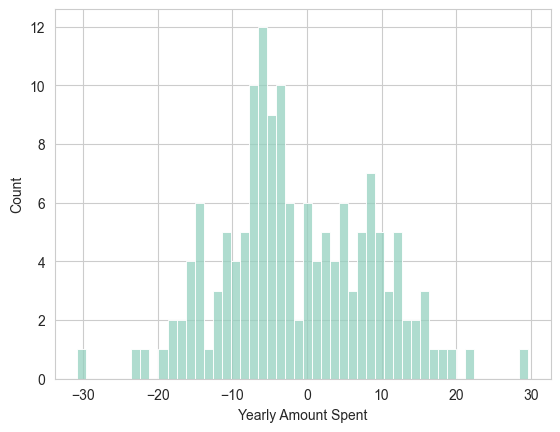

```python
sns.histplot((y_test - predictions), bins=50)
```

### Análise do histograma dos resíduos

O histograma dos resíduos (diferença entre valores reais e preditos) apresenta uma distribuição aproximadamente normal, centrada em torno de zero. Isso indica que os erros do modelo são distribuídos de forma equilibrada, sem viés evidente, sugerindo que o modelo de regressão linear se ajusta bem aos dados e não apresenta padrões de erro sistemáticos.

## Conclusão

Ainda desejamos descobrir a resposta à pergunta original, concentramos-nos no desenvolvimento de aplicativos móveis ou de sites? Ou talvez isso realmente não importe, e o tempo como membro é o que é realmente importante? Vamos ver se podemos interpretar os coeficientes para ter uma idéia.

Recrie o quadro de dados abaixo.

```python
coeffecients = pd.DataFrame(lm.coef_, X.columns)
coeffecients.columns = ["Coeffecient"]
coeffecients
```

|  | Coeffecient |
| --- | --- |
| Avg. Session Length | 25.724256 |
| Time on App | 38.597135 |
| Time on Website | 0.459148 |
| Length of Membership | 61.674732 |

**Como você pode interpretar esses coeficientes?**

Interpretando os coeficientes:

- Mantendo todos as outras variáveis constantes: um aumento de 1 unidade na média de tempo de uso está associado a um aumento de 25,72 dólares totais gastos.
- Mantendo todos as outras variáveis constantes: um aumento de 1 unidade no tempo gasto no App está associado a um aumento de 38,59 dólares totais gastos.
- Mantendo todos as outras variáveis constantes: um aumento de 1 unidade no tempo no site está associado a um aumento de 0,45 dólares em dólares.
- Mantendo todos as outras variáveis constantes: um aumento de 1 unidade no tempo de Associação está associado a um aumento de 61,67 dólares em dólares.

**Você acha que a empresa deve se concentrar mais em seu aplicativo móvel ou em seu site?**

Primeiramente, a empresa provevelmente deveria arranjar outras formas de fidelizar seu cliente, já que essa é a variável que mais ifluenciam os gastos dos seus usuários. Entre site e aplicativo, investiriamos no aplicavo, dado que o mesmo apresenta um coeficiente significativamente maior do que o site.